# Getting data out of the web with R

Intro to R, lecture 7

Paolo Crosetto

2021-10-18

# 1. Extraire des données du *web*

## Quelques bases “théoriques”

Le web est rempli de données. Il est *fait* pour la plupart de données. De plus, les pages web sont de plus en plus elle mêmes générées par des logiciels.

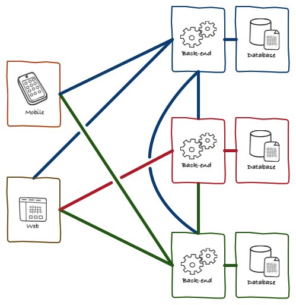

Un site web est le résultat de trois éléments: - une **base de données** - un **back-end** qui fait des opérations sur les données suivant une **logique** propre à chaque page / appli / service - un **front-end** qui n’est qu’une coquille d’affichage ‘vide’ qui va être remplie par le *back-end* en utilisant les données de la *base de données*.

Un exemple: **IMDB**: https://www.imdb.com/chart/boxoffice

Le développeur web: 1. conçoit et met en place le *back-end*, l’affichage des informations dans une grille logique; puis 2. prend soin de la mise en page, de l’esthétique, etc; mais 3. il laisse à des moteurs comme *PHP* ou autres s’occuper de *peupler* les pages avec leur contenu (soient-ils des vidéos youtube, des images, des contacts, le profil facebook d’une personne, etc…).

**Extraire des données du web** veut dire **remonter le fil** – faire du *reverse-engineering*: extraire les données qui ont contribué à créer la page qu’on voit.

Ce processus s’appelle **scraping**.

Malheureusement, ces données sont utilisées par les sites pour afficher de l’information. Par conséquence, même si le format d’origine des données est un format qui est facile d’utiliser pour des statistiques, le format des données tel qu’on le voit sur les écrans a été optimisé pour la visualisation par des êtres humains: les données sont éparpillées sur l’écran et sur différentes pages, il faut cliquer, etc…

Il faut donc trouver des moyens d’extraire l’énorme richesse de données présente sur le web pour nos usages statistiques.

## Comment faire? API – entrée directe sur la base

Quelques sites fournissent un API – des fonctions spécialisés pour accéder directement à la base de données du site. (Par exemple: twitter, skyscanner, deezer…) (https://rapidapi.com/blog/most-popular-api/)

Si votre source a une api – *go for it!*

## Comment faire? scraping – exploiter les **patterns**.

La plupart des sites n’a pas d’API. Dommage. On va devoir gratter.

- les données ‘cachées’ sur le web souvent suivent un *pattern* particulier;
- si on pense à la date et heure des tweets, elles se trouvent toujours au même endroit sur la page et ont toujours le même format. Même chose pour les posts sur Facebook. Même chose pour les pages d’un blog.
- En exploitant ces regularités on peut à notre tour utiliser des logiciels pour collecter (**scrap**) les données d’un site.

Il y a quatre choses à faire pour extraire les données d’un site:

1. *retrieve*: télécharger le code source des pages web (en HTML).
2. *parse*: lire leur contenu et chercher les données qui nous intéressent
3. *crawl*: itérer ce processus sur plusieurs pages
4. *store*: stocker les données dans un format convenable: `data.frame()` ou `tibble()`

Dans la suite on va présenter le fonctionnement de deux packages:

1. `rvest`: partie du tidyverse, compatible avec notre cours mais pas de crawl;
2. `RCrawler`: plus puissant mais pas 100% compatible.

## Retrieve and parse **one** webpage: `rvest`

On commence par installer le package. Il est partie du tidyverse, mais on ne sait jamais:

```r
#install.packages("rvest")
library(rvest)
```

`rvest` travaille en trois étapes

1. *read*: lecture et importation de la page html
2. *select*: sélection du matériel qu’il nous faut à l’intérieur de la page
3. *parse*: extraction du matériel et stockage dans R.

### **Premier cas: extraire un tableau déjà formé**

#### *read*

example: liste des états des EE.UU. par population, disponible par exemple [sur wikipedia en anglais simplifié](https://simple.wikipedia.org/wiki/List_of_U.S._states_by_population).

```r
usa <- read_html("https://simple.wikipedia.org/wiki/List_of_U.S._states_by_population")
```

`rvest` a stocké pour nous la page.

#### *select*

Comment extraire de l’info?

Il faut à ce point chercher dans la page à l’aide d’un CSS selector. Tous les éléments d’une page web qui ont le même format d’affichage ont le même ‘thème’ CSS. Il y a donc des outils automatisés qui permettent de sélectionner le CSS path ou son selector sur une page, de façon visuelle à l’aide de la souris.

**Nous allons utiliser Selectorgadget, une extension pour Chrome/Chromium, ici: https://selectorgadget.com/**

Si vous ne voulez pas utiliser Selectorgadget, chaque navigateur a des outils développeur (normalement CTRL+SHIFT+I)

Une fois selectorgadget installé, on peut simplement en cliquant sur les éléments connaitre leur CSS path et ainsi les sélectionner sur notre page téléchargée.

Une fois le XPATH ou le CSS selector pour l’élément qui nous intéresse trouvés, il faut dire à `rvest` de nous sortir tous les éléments de la page qui suivent le pattern voulu. Dans notre cas, on veut trouver le tableau. Celui ci est un div `table`. On sélectionne les parties qu’on veut à l’aide de `html_elements(pagehtml, "CSS SELECTOR")`

```r
usa %>% html_element(".wikitable")
```

```
## {html_node}
## <table class="wikitable sortable" style="width:100%; text-align:center;">
## [1] <tbody>\n<tr style="vertical-align: top;">\n<th style="vertical-align: mi ...
```

On va donc l’extraire:

```r
states <- usa %>% html_element(".wikitable")
```

#### *parse*

On a maintenant isolé le tableau dont on avait besoin. Comment l’importer en R pour l’utiliser pour nos stats? Deux étapes:

1. sortir le tableau de la liste où il est caché;
2. utiliser la fonction `html_table()`:

```r
states %>%
  html_table() -> df
```

on va inspecter un peu notre df

```r
## recap

# lire la page
# read_html(URL)
# html_node(s) -> une fois sélectionnés les nodes avec un CSS selector
# html_table()  -> imorter dans R en data frame

df
```

```
## # A tibble: 60 × 12
##    `Rank in states … `Rank in states … State  `Population esti… `Census populat…
##    <chr>             <chr>             <chr>  <chr>             <chr>
##  1 1                 1                 Calif… 39,512,223        37,254,523
##  2 2                 2                 Texas  28,995,881        25,145,561
##  3 3                 4                 Flori… 21,477,737        18,801,310
##  4 4                 3                 New Y… 19,453,561        19,378,102
##  5 5                 6                 Penns… 12,801,989        12,702,379
##  6 6                 5                 Illin… 12,671,821        12,830,632
##  7 7                 7                 Ohio   11,689,100        11,536,504
##  8 8                 9                 Georg… 10,617,423        9,687,653
##  9 9                 10                North… 10,488,084        9,535,483
## 10 10                8                 Michi… 9,986,857         9,883,640
## # … with 50 more rows, and 7 more variables:
## #   Percent change, 2010–2019[note 1] <chr>, Absolute change, 2010-2019 <chr>,
## #   Total seats in the U.S. House of Representatives, 2013–2023 <chr>,
## #   Estimated population per electoral vote, 2019[note 2] <chr>,
## #   Estimated population per House seat, 2019 <chr>,
## #   Census population per House seat, 2010 <chr>,
## #   Percent of the total U.S. population, 2018[note 3] <chr>
```

Il n’est pas parfait, mais presque. Et cela a pris 5 lignes de code.

> exercice: révision du tidyverse: barplot de la croissance de la population par état

**Attention**: - toutes les données sont des chaines de caractères!! - il y a des lignes agrégées dont nous n’avons pas besoin (`table(df$State)` pour les voir)

> rvest table exercice: extraire les données d’un tableau sur wikipedia
- Extraire les données du tableau https://en.wikipedia.org/wiki/List_of_African_countries_by_GDP_(PPP)_per_capita
- quels sont les états plus riches? faire un barplot du GDP par pays (attention: les données sont en caractère!)

```r
# partie 1: on scrape les données

# étape 1: lire la page web et importer en R les données

## partie 2: on nettoye les données


## partie 3: le graphique
```

> un exemple plus complexe: les spectateurs de Game of Thrones

Obectif: reproduire le graphique des spectateurs de GoT par saison.

La page web contenant les données est ici: https://en.wikipedia.org/wiki/Game_of_Thrones#Viewership

```r
#extract the data


# clean the data


# plotting
```

### **Deuxième cas: extraire de l’info d’un texte**

Et si l’info qu’on cherche est dans un texte et non pas déjà pre-formattée en tableau?

#### Sites ‘faits à la main’: pas cool.

On va travailler, pour éviter de voler des données à n’importe qui, sur ma liste des publications, disponible sur [mon site personnel](https://paolocrosetto.wordpress.com/papers/)

Les étapes de *read* et de *select* sont les mêms que pour les tableaux:

```r
pc <- read_html("https://paolocrosetto.wordpress.com/papers/")
```

à l’aide du CSS selector on s’aperçoit que tout titre d’un papier est dans un tag `strong`.

On va donc extraire les titres de tous les publications.

`rvest` utilise pour le texte la fonction `html_text`:

```r
publis <- pc %>% html_elements("li strong") %>% html_text()
```

On utilise la fonction `html_elements()` pour *select*ionner les titres et la fonction `html_text()` pour en *parse*r le texte.

Les données sont stockés dans un vecteur.

```r
publis %>% kable()
```

| x |
| --- |
| What are you calling intuitive? Subject heterogeneity as a driver of response times in an impunity game |
| The Acceptability of Accountability |
| The long-term effects of self pledging in reward crowdfunding |
| Attacking the weak or the strong? An experiment on the targets of parochial altruism |
| Central Tendency Bias in Belief Elicitation |
| The experience matters: participation-related rewards increase the success chances of crowdfunding campaigns |
| Modelling the impact of different front-of-package nutrition labels on mortality from non-communicable chronic disease |
| Nutritional and economic impact of 5 alternative front-of-pack nutritional labels: experimental evidence |
| A flexible z-Tree and oTree implementation of the Social Value Orientation Slider Measure |
| Representation effects in the Centipede game |
| It’s never too late: funding dynamics and self pledges in crowdfunding. |
| Choosing not to compete: Can firms maintain high prices by confusing consumers? |
| Better stuck together or free to go? Of the stability of cooperation when |
| individuals have outside options. |
| The Sound of Others: Surprising Evidence of Conformist Behavior |
| Modification des achats alimentaires en réponse à cinq logos nutritionnels |
| A Reconsideration of Gender Differences in Risk Attitudes |
| A Theoretical and Experimental Appraisal of Four Risk Elicitation Methods |
| Intellectual property rights hinder sequential innovation: experimental evidence |
| Helping consumers with a front-of-pack label: numbers or colours? Experimental comparison between Guideline Daily Amount and Traffic Light in a diet-building exercise |
| A Monetary Measure of the Strength and Robustness of the Attraction Effect |
| Click’n’Roll: No Evidence of Illusion of Control |
| Réponses des consommateurs à trois systèmes d’étiquetage nutritionnel face avant |
| A Study of Outcome Reporting Bias Using Gender Differences in Risk Attitudes |
| , |
| The ‘Bomb’ Risk Elicitation Task |
| To patent or not to patent: a pilot experiment on incentives to copyright in a sequential innovation setting |
| Fast then Slow: A Choice Process Explanation for the Attraction Effect |
| Safe options induce gender differences in risk attitudes |
| Motives of Sanctioning: Equity and Emotions in a Public Good Experiment with Punishment |
| Turning private vices into collective virtues: a simple model and an experiment on the SourceForge development community |
| Social norms, social multipliers and nutrition public policies: an experiment |
| Experimental evaluation of the performance of nutritional labels and price policies |
| Hoping for, Receiving and Accepting Gifts. A Neuroeconomics Experiment |
| Rise and fall of asymmetric dominance |
| Individual versus Collective Punishment: an Intergroup Public Good Experiment |
| Il ‘miracolo americano’ della produttività e l’Europa. Fine della convergenza?, |
| Il ‘miracolo americano’ della produttività e l’Europa. Fine della convergenza? |
| La Direttiva Bolkestein: vicissitudini e problemi aperti |
| Capitolo 8: Russia, |
| Capitolo 9: Ucraina |
| Competition and cooperation: Italian SMEs go international |
| The Case for Weaker IP Regulations |
| L’importanza economica della peer production (in Italian) |
| Russia. Fine della ricostruzione, inizio di una nuova era? (in Italian) |
| Data analysis on the 2009 European Parliamentary Elections (in Italian) |

Il y a quelques ‘publications’ qui ne sont que des titres de section, ou des virgules… pas très bien fait ce site!

Cet exemple vous montre que parfois sortir l’information n’est pas facile parce que le site est fait ‘à la main’ (c’est mon cas) et donc ne suit pas des normes spécifiques qui créent des patterns exploitables par nos logiciels.

#### Sites faits de façon professionnelle: plus facile.

Il est plus facile d’extraire des données des sites ‘professionnels’.

Par exemple, extraire la liste des blog posts du site de Rstudio. On va chercher le blog de Rstudio ici: https://blog.rstudio.com/

```r
rstudio <- read_html("https://blog.rstudio.com/")
```

Après avec l’aide du CSS selector on peut sélectionner par exemple les auteurs. Si on le fait on voit que les dates sont sélectionnées aussi. mais si on clique sur une date on peut déselctionner les dates.

Avec des opérations de ce type on peut construire une base de données assez importante, **sur une seule page à la fois**.

> exercice: extraire les titres, années, et nombre d’étoiles des 250 meilleurs films selon IMDB
- importer https://www.imdb.com/chart/top/
- lire les infos et en faire une base de données
- on veut le titre, l’année et le nombre d’étoiles par film (il y en a 250)
- faire un histogramme des années les plus répresentées

```r
# 1. lire la page web
imdb <- read_html("https://www.imdb.com/chart/top/")

#2. pour chaque élement chercher le node et applquer html_text

# titres


# date


# étoiles


#3. coller les vecteurs ensemble avec "tibble()"


#4. nettoyage des données


#5. plot : histogram of date
```

## Crawling: automatiser le processus

Ce processus est long, et devoir le refaire pour chaque page d’un site serait très long. Heureusement il existe un autre type d’outils, les *crawlers*. Ce que les crawlers font est de télécharger toutes les sous-pages d’un site à partir d’une page de départ. Autrement dit: on leur donne une page d’où partir, et le crawler va essayer de télécharger, une après l’autre, toutes les pages ‘filles’ de cette page, celles qui la succèdent dans la hiérarchie du site.

Le couplage d’un *crawler*, d’un extracteur et d’un parseur permet d’automatiser l’extraction des données d’un site complet.

Malheureusement, il n’y a pas d’outil lié au tidyverse qui fait cette opération complexe. L’outil qu’on va utiliser est le package `Rcrawler`.

```r
#install.packages("Rcrawler")
library(Rcrawler)
```

Dans ce cas, tout le blog de rstudio fait des centianes des pages, dont on n’a pas besoin; si on lance Rcrawler sans argument, on se retrouve avec plus de 400 pages. Quoi faire? En regardant sur le site, on voit, en cliquant sur les pages suivantes la première, que chaque URL est formé an ajoutant `\page\NUMPAGE\` à l’URL principal. Heuresement Rcrawler nous permet de filtrer les pages qu’on veut télécharger. La commande est la suivante:

```r
Rcrawler(Website = "https://blog.rstudio.com/", crawlUrlfilter = "/page/[0-9]{1-2}" )
```

[output not shown]

Rcrawler a crée une variable INDEX dans votre environnement, qui contient chaque page, et la réponse donnée par le serveur (dans ce cas, réponse 200, c’est à dire OK.) Il a aussi stocké toutes les pages localement dans un dossier, où maintenant chaque page du blog de Rstudio est sauvegardée localement.

Ce qu’on vient de faire est la partie *crawling*: notre crawler a passé au peigne fin le site et nous a téléchargé toutes les pages. Il n’a pas extrait des données. On a deux façon de poursuivre: utiliser le code de `rvest` décrit ci-dessus en l’applicant à chaque page avec une boucle; ou bien laisser faire RCrawler. La première voie est assez simple (je vous laisse faire en exercice), là je décris la deuxième.

Rcrawler à une option `ExtractCSSPat = c(LISTE DE PATTERNS)` qui permet d’extraire les champs qu’on veut au passage. On sait quels champs on veut (voir le code ci-dessus). Donc il suffit de le lancer:

```r
Rcrawler(Website = "https://blog.rstudio.com/",
         crawlUrlfilter = "/page/[0-9]{1-2}",
         ExtractCSSPat = c("span+ span","h1 a",".article-list span:nth-child(1)"),
         MaxDepth = 100,
         ManyPerPattern = T,
         PatternsNames = c("author","title","date"))
```

[output not shown]

[output cut: 26 more lines]

[output not shown]

Cette fois ci Rcrawler a crée deux variables dans votre environnement: INDEX et DATA.

Là on a tout ce qu’il faut; mais malheureusement les données sont dans un format de lecture difficile: DATA est une liste et chacun de ses éléments est aussi une liste, qui contient à son tour les données qu’on cherche. Il faut passer d’une liste de listes à un data.frame facile à lire et utiliser.

```r
tibble(DATA) %>%
  mutate(ext = map(DATA, ~data.frame(do.call("cbind", .)))) %>%
  unnest(ext) -> rstudio_data
```

et voilà, on a extrait tous les blog posts du blog de Rstudio.

On peut meinatenant faire un contage pour voir qui a publié plus de posts, et faire un plot:

[figure not shown]

```r
rstudio_data %>%
  ggplot(aes(x = author))+
  geom_bar()+
  coord_flip()
```

## Un autre example

> exercice: Rcrawler
- Télécharger les pages des jeux sur newgrounds: https://www.newgrounds.com/games
- Pour chaque jeu, télécharger:
  - le nombre de ‘views’
  - le nombre de ‘votes’
  - le ‘score’
  - l’auteur

```r
Rcrawler(Website = "https://www.newgrounds.com/games",
         crawlUrlfilter = "/portal/view/",
         dataUrlfilter = "/portal/view/",
         ExtractCSSPat = c("#embed_header .rated-e", "#sidestats > .sidestats:nth-child(1) dd:nth-child(2)", "dd:nth-child(8)"),
         PatternsNames = c("title", "views", "stars"))
```

[output not shown]

Puis transformer DATA en tibble:

```r
DATA %>%
  tibble() %>%
  mutate(ext = map(DATA, ~data.frame(do.call("cbind", .)))) %>%
  unnest(ext) -> games
```

Quel est parmi ces jeu le plus vu?

```r
games %>%
  mutate(views = as.numeric(views)) %>%
  arrange(-views)
```

```
## # A tibble: 21 × 5
##    .                PageID title           views stars
##    <list>           <chr>  <chr>           <dbl> <chr>
##  1 <named list [4]> 2      Ninjack Rabbit    469 "\n\t\t\t\t\t\t\t\t\t\t\t3.93 …
##  2 <named list [4]> 1      <NA>              298 "\n\t\t\t\t\t\t\t\t\t\t\t3.73 …
##  3 <named list [4]> 3      Block Collide      NA "\n\t\t\t\t\t\t\t\t\t\t\t3.90 …
##  4 <named list [4]> 4      Estresamente       NA "\n\t\t\t\t\t\t\t\t\t\t\t3.60 …
##  5 <named list [4]> 5      The Lesser Evil    NA "\n\t\t\t\t\t\t\t\t\t\t\t4.00 …
##  6 <named list [4]> 6      Crazy Cauldron     NA "\n\t\t\t\t\t\t\t\t\t\t\t3.72 …
##  7 <named list [4]> 7      Dogs++             NA "\n\t\t\t\t\t\t\t\t\t\t\t4.03 …
##  8 <named list [4]> 8      <NA>               NA "\n\t\t\t\t\t\t\t\t\t\t\t4.07 …
##  9 <named list [4]> 9      <NA>               NA "\n\t\t\t\t\t\t\t\t\t\t\t4.35 …
## 10 <named list [4]> 10     <NA>               NA "\n\t\t\t\t\t\t\t\t\t\t\t4.28 …
## # … with 11 more rows
```